# Assignment 9

MJKelleher

March 04, 2018

## Harry Potter Cast

### (a.) [View the cast members for the movies, understand the structure of the HTMl/XML](http://www.imdb.com/title/tt1201607/fullcredits?ref_=tt_ql_1)

### (b.) Scrape the page, collecting all of the cast.

```r
url <- "http://www.imdb.com/title/tt1201607/fullcredits?ref_=tt_ql_1"
#
# If you use TRUE, the URL gets parsed as the actual content, not the contents of the URL#
html <- htmlParse(url, asText=FALSE)

cleanCharacterNames = function(x){
    clean <- xmlValue(x)
    clean <- gsub("\\n", " ", clean)
    clean <- gsub("[[:space:]]+", " ", clean)
    clean <- trimws(clean)
    clean
}

# Collect the Actor names
xpath <- "//table[@class='cast_list']//span[@itemprop='name']"
castNames <- xpathSApply(html, xpath, xmlValue)

# Collect the Character Names
xpath <- "//table[@class='cast_list']//td[@class='character']/div"
castCharacters <- xpathSApply(html, xpath, cleanCharacterNames)

# Cross Check the sizes of the 2 Vectors BEFORE creating the dataframe
if (length(castNames) == length(castCharacters)) {
    castdf <- data.frame(castNames, castCharacters)
    names(castdf) <- c("Actor", "Character")
} else {
    sprintf("Cast vector size is %d, Characters vector size is %d, and they DO NOT match", length(castNames), length(castCharacters))
}
```

### (c.) Clean up the Table

```r
FirstName <- sub("^(.*) [^ ]*$", "\\1", castNames,perl=TRUE)
SurName <- sub("^.* ([^ ]*)$", "\\1", castNames,perl=TRUE)

castdf <- data.frame(FirstName, SurName, castCharacters)
names(castdf) <- c("FirstName", "SurName", "Character")
```

### (e.) Print the first 10 Rows

```r
head(castdf,n=10)
```

```
##    FirstName   SurName                            Character
## 1      Ralph   Fiennes                       Lord Voldemort
## 2    Michael    Gambon           Professor Albus Dumbledore
## 3       Alan   Rickman              Professor Severus Snape
## 4     Daniel Radcliffe                         Harry Potter
## 5     Rupert     Grint                          Ron Weasley
## 6       Emma    Watson                     Hermione Granger
## 7     Evanna     Lynch                        Luna Lovegood
## 8   Domhnall   Gleeson                         Bill Weasley
## 9   Clémence     Poésy                       Fleur Delacour
## 10   Warwick     Davis Griphook / Professor Filius Flitwick
```

## SportsBall

### (a.) Understand the structure of [ESPN San Antonio Spurs player stats page](http://www.espn.com/nba/team/stats/_/name/sa/san-antonio-spurs), and more specifically the Shooting Statistics table.

### (b.) Scrape the Shooting Statistics table

```r
    url <- "http://www.espn.com/nba/team/stats/_/name/sa/san-antonio-spurs"
    html <- htmlParse(url, asText=FALSE)

    xpath <- "//table[*//text()='SHOOTING STATISTICS']//tr[contains(@class,'player')]"
    rows <- getNodeSet(html, xpath)

    getEachRow = function(x) {
      c_row <- xmlChildren(x)
      row <- as.character(sapply(c_row, xmlValue))
    }
    fixColumn = function(x) {
      newrow <- as.numeric(x)
      if (sum(is.na(newrow)) > 0) {
        newrow <- x
      }
      newrow
    }
```

### (c.) Clean up the table: one observation per row, no blank rows, the column names or the “Totals” row. Additionally, split the “PLAYER” column into 2 columns: 1 for name, 1 for position. Lastly, make sure each column uses the correct data type for its contents, numbers for the stats columns, etc.

```r
    table <- sapply(rows, getEachRow)
    rownames(table) <- c()
    table <- t(table)
    playerStats <- as.data.frame(table, stringsAsFactors = FALSE)

    thenames <- c("playerpos", "FGM", "FGA", "FGPct", "3PM", "3PA", "3PPct", "FTM", "FTA", "FT%", "2PM", "2PA", "2PPct", "PPS", "AFGPct")
    names(playerStats) <- thenames
    playerStats <- lapply(playerStats, fixColumn)
    playerStats$player_name <- gsub("(^[^,]*),.*", "\\1", playerStats$playerpos, perl=TRUE)
    playerStats$player_pos <- gsub("[^,]*,(.*)$", "\\1", playerStats$playerpos, perl=TRUE)
    playerStats$playerpos <- NULL
```

### (d.) Colorful bar chart that shows the Field Goals Percentage Per Game for each person

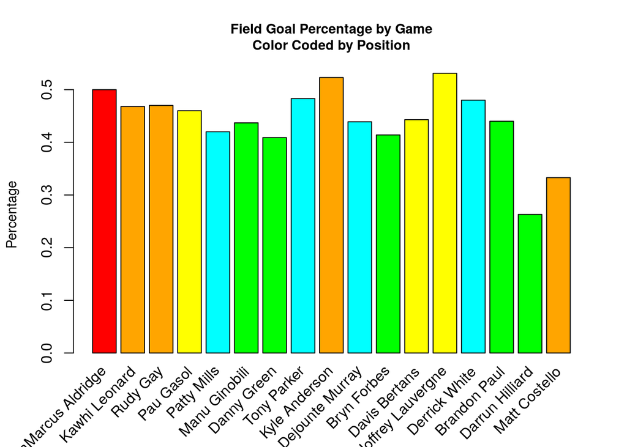

```r
    colors <- c("red", "orange", "yellow", "cyan", "green", "blue", "purple", "darkgrey" , "turquoise", "black" )

    color_dict <- list()
    unique_pos <- unique(playerStats$player_pos)
    for (ndx in 1:length(unique_pos)) {
        color_dict[[ unique_pos[ndx] ]] <- colors[ndx]
    }

    the_colors <- lapply(playerStats$player_pos, function(x) color_dict[[x]] )
    the_colors <- as.character(the_colors)

    plplt <- barplot(playerStats$FGPct, main="Field Goal Percentage by Game\nColor Coded by Position", ylab = "Percentage",
            cex.lab = .9, cex.main = .9, cex.names = .6, beside=TRUE, col=the_colors)
    text(plplt, par("usr")[3] - 0.025, srt = 45, adj = 1, labels = playerStats$player_name, xpd = TRUE, font = 1)
```